# Estimating K600 from streammetabolizer for BWU

Kelly Loria

2025-01-31

## Background

This is a small, turbulent, shaded, streamed with a fair amount of fine particulate organic matter.

## Identifying reasonable modeled estimates of K600

We then ran the normal stream metabolizer model: `b_Kb_oipi_tr_plrckm.stan` to get modeled K600 to see if we could resolve the negative correlation between ER and K600. Priors on `K600_lnQ_nodes_meanlog` were set as 5 bins based on `rnorm(1000, mean = logQ_mean, sd = logQ_sd)` centered around the mean and logQ va;ues 1-2 sd away from the mean.

### Metabolism segements with CIs

Where GPP is in blue and ER is in orange.

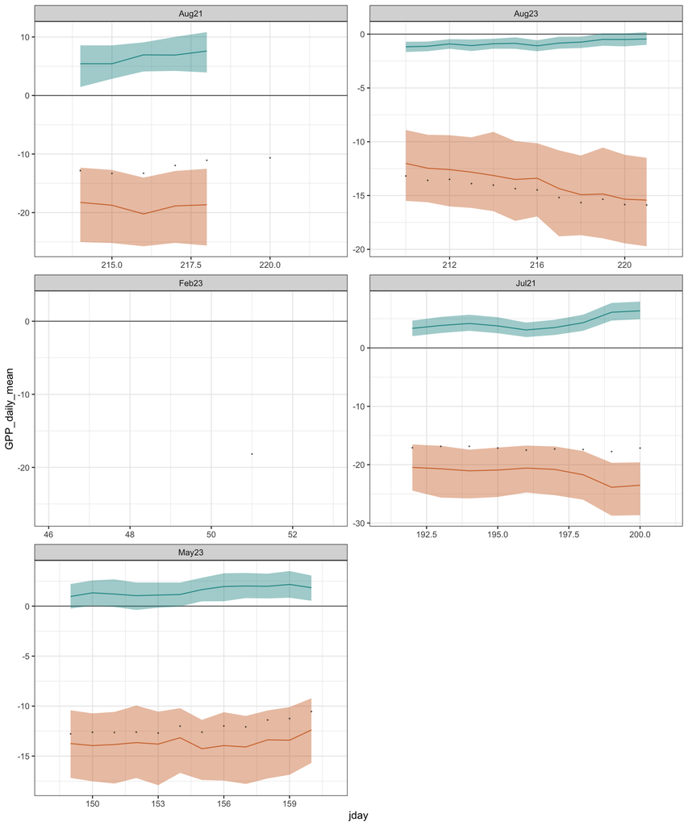

## Checking model convergence

** Not all all segments had great convergence.

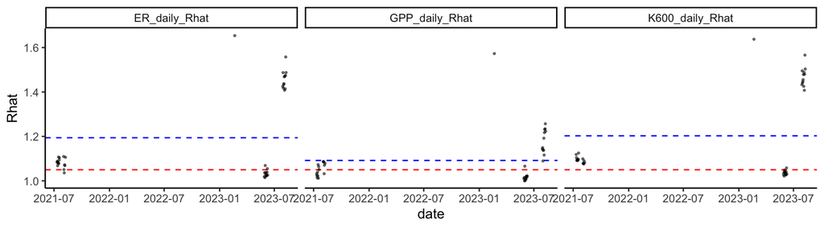

```
##       date                lab                 rmse               sd
##  Min.   :2021-07-10   Length:114         Min.   :0.03882   Min.   :0.05391
##  1st Qu.:2021-08-04   Class :character   1st Qu.:0.06286   1st Qu.:0.15946
##  Median :2023-02-22   Mode  :character   Median :0.11266   Median :0.29200
##  Mean   :2022-09-26                      Mean   :0.22806   Mean   :0.40698
##  3rd Qu.:2023-06-10                      3rd Qu.:0.21019   3rd Qu.:0.39388
##  Max.   :2023-08-10                      Max.   :1.31174   Max.   :1.63161
##                                          NA's   :34
##       min             max             range            nrmse
##  Min.   :3.755   Min.   : 5.394   Min.   :0.1827   Min.   :0.03883
##  1st Qu.:5.318   1st Qu.: 7.001   1st Qu.:0.5807   1st Qu.:0.06476
##  Median :6.487   Median : 7.620   Median :0.9253   Median :0.17466
##  Mean   :6.836   Mean   : 8.119   Mean   :1.2837   Mean   :0.15487
##  3rd Qu.:9.080   3rd Qu.: 9.601   3rd Qu.:1.1547   3rd Qu.:0.21286
##  Max.   :9.503   Max.   :10.270   Max.   :5.1407   Max.   :0.28999
##                                                    NA's   :34
##       minT             maxT            rangeT
##  Min.   : 1.003   Min.   : 1.765   Min.   :0.05967
##  1st Qu.: 2.198   1st Qu.: 5.571   1st Qu.:3.13400
##  Median : 8.465   Median :15.504   Median :5.62767
##  Mean   : 6.892   Mean   :11.557   Mean   :4.66453
##  3rd Qu.:10.792   3rd Qu.:16.790   3rd Qu.:6.38467
##  Max.   :12.162   Max.   :18.060   Max.   :7.61333
##
```

## Looking at the K600 and ER relationships

Here is the run configuration:

**bayes_specs_new**

`bayes_name_new <- mm_name(type = 'bayes', pool_K600 = "normal", err_obs_iid = TRUE, err_proc_iid = TRUE, ode_method = "trapezoid", deficit_src = 'DO_mod', engine = 'stan')`

Where each “lab” segment was run as individual model with the `K600_lnQ_nodes_meanlog` adjusted to match streamline in cms during that time.

### K-ER, K-Q, general K600 trends

```r
met.clean <- met.df %>%
  filter(GPP_daily_Rhat<1.1)%>%
  filter(GPP_97.5pct>0)%>%
  filter(ER_daily_Rhat<1.1) %>%
  filter(ER_2.5pct<0)%>%
  filter(K600_daily_Rhat<1.1)


ker <- ggplot(met.clean, aes(x = K600_daily_mean, y = ER_daily_mean, col = as.factor(lab)))+
  geom_point(size = 2)+
  theme_bw()+ geom_smooth(method="lm", se=F, color="grey50") +
  scale_color_viridis_d(option = "inferno") +  theme(legend.position = "null")


KER_cor <- round(cor(met.clean$ER_daily_mean, met.clean$K600_daily_mean, use = "complete.obs"),3)
print(KER_cor)
```

```
## [1] 0.841
```

```r
KGPP_cor <-round(cor(met.clean$GPP_daily_mean, met.clean$K600_daily_mean, use = "complete.obs"),3)
print(KGPP_cor)
```

```
## [1] -0.944
```

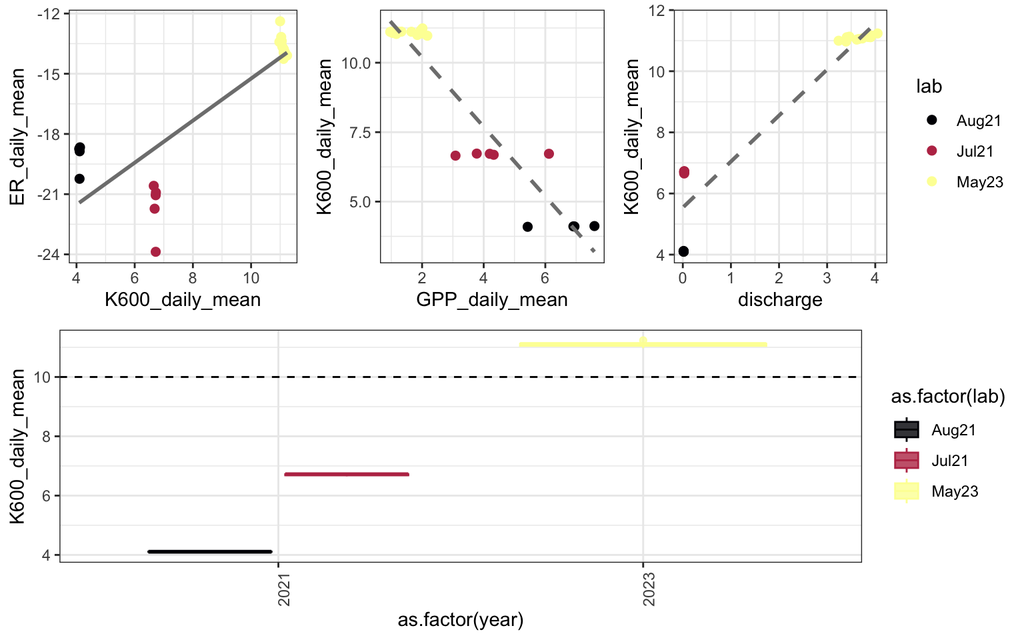

```r
kgpp <- ggplot(met.clean, aes(y = K600_daily_mean, x = GPP_daily_mean, col = as.factor(lab)))+
  geom_point(size = 2)+  geom_smooth(method="lm", se=F, color="grey50", lty="dashed") +
  theme_bw()+
  scale_color_viridis_d(option = "inferno") +
  theme(legend.position = "null")

kyear <- met.clean %>%
ggplot(aes(x = as.factor(year), y = K600_daily_mean, fill = as.factor(lab), col = as.factor(lab)))+
    geom_hline(yintercept = 10, lty = 2)+
  geom_boxplot(alpha = 0.8)+
  theme_bw()+
  scale_fill_viridis_d(option ="inferno") +  # Use _d for discrete
  scale_color_viridis_d(option = "inferno") +
  theme(axis.text.x = element_text(angle = 90, hjust = 1))

mod.env.ag <- input_dat%>%
  mutate(date= as.Date(solar.time))%>%
  group_by(date) %>%
  dplyr:: summarise(
    DO.obs = mean(DO.obs, na.rm=T),
    DO.sat = mean(DO.sat, na.rm=T),
    depth = mean(depth, na.rm=T),
    temp.water = mean(temp.water, na.rm=T),
    light = mean(light, na.rm=T),
    discharge =  mean(discharge, na.rm=T))


k.q <- met.clean %>%
  left_join(mod.env.ag, by = "date") %>%
  ggplot(aes(x = discharge, y = K600_daily_mean, col = lab))+
  geom_point( size = 2)+ geom_smooth(method="lm", se=F, color="grey50", lty="dashed") +
  theme_bw()+
  #scale_x_log10(limits = c(20, 800))+
   scale_color_viridis_d(option = "inferno")



p1 <- plot_grid(ker, kgpp, k.q, rel_widths =c(0.3, 0.3, 0.4), ncol = 3)
plot_grid(p1, kyear, ncol = 1)
```

### Compared modeled and measured K600

Plots for (1) measured v modeled K600 and flow and (2) logK600 and log(flow+1).

```r
mean_k_mod <- mean(met.clean$K600_daily_mean)
mean_k_mod
```

```
## [1] 8.717534
```

```r
mean_k_measure <- mean(measured_K$K600)
mean_k_measure
```

```
## [1] 22.96813
```

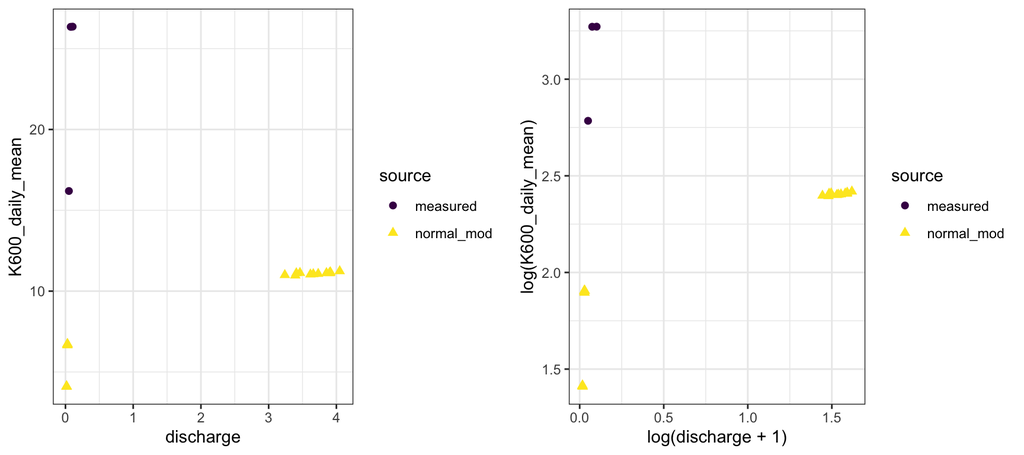

```r
k.q <- met.clean %>%
  left_join(mod.env.ag, by = "date") %>%
  full_join(measured_K, by = c("date", "source",
                                 "K600_daily_mean"= "K600",
                                "discharge"= "Q_cms")) %>%
  ggplot(aes(x = discharge, y = K600_daily_mean, col = source, shape=source))+
  geom_point( size = 2) +
  theme_bw()+
  #scale_x_log10(limits = c(20, 800))+
   scale_color_viridis_d(option = "viridis")


k.q_log <- met.clean %>%
  left_join(mod.env.ag, by = "date") %>%
  full_join(measured_K, by = c("date", "source",
                                 "K600_daily_mean"= "K600",
                                "discharge"= "Q_cms")) %>%
  ggplot(aes(x = log(discharge+1), y = log(K600_daily_mean), col = source, shape=source))+
  geom_point( size = 2) +
  theme_bw()+
  #scale_x_log10(limits = c(20, 800))+
   scale_color_viridis_d(option = "viridis")



plot_grid(k.q, k.q_log, ncol = 2)
```

```r
possible_k <- (mean_k_mod+mean_k_measure)/2
possible_k
```

```
## [1] 15.84283
```